# Markov chains

Jeffrey Chrabaszcz  
14 January 2014

### Outline

1. Fixing a mistake
2. Likelihood calculation for continuous variables
3. Maximizing likelihood
4. Markov chains

### Fixing a mistake

Yesterday I listed the objective function as:

\[ \hat{\ell}(\theta|x) = \frac{1}{n}\sum_{i = 1}^n \ln f(x_i|\theta) \]

But had you calculate a likelihood using:

```r
sum(dpois(obs, rate))
```

This code is wrong! Fixing it might yield some insight into how likelihood calculation works.

### Unions

We need two pieces of information to make this work. The first is:

\[ P(A \cup B) = P(A) \cdot P(B) \]

The second is that:

\[ log(A \cdot B) = log(A) + log(B) \]

We can think of the objective function as the joint probability of each piece of data having been observed, given the parameter/hypothesis.

### Correcting our code

This means that our code should have read:

```r
prod(dpois(obs, rate))
```

Unfortunately, this can lead to values so small that it's hard for computers to easily keep track of them, (I'm not kidding). Instead, we use the form:

```r
exp(sum(log(dpois(obs, rate))))
```

We take a natural logarithm so we can add values together, then exponentiate so we can view the result on a standard scale.

### Likelihood calculation for continuous variable

The normal distribution is defined for all possible values of X. Say we sample five values from a standard normal distribution.

```
[1]  0.540 -0.503 -0.620  0.070  0.157
```

We can visualize the probability density associated with each of these samples assuming \( \mu = 0 \) and \( \sigma = 1 \) on the following graph.

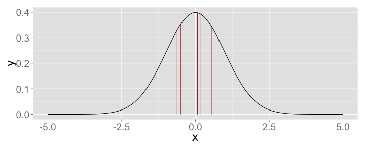

### Heights of lines

The heights of those lines are dictated by the parameters of the normal distribution. That means we can change the heights by changing the parameters!

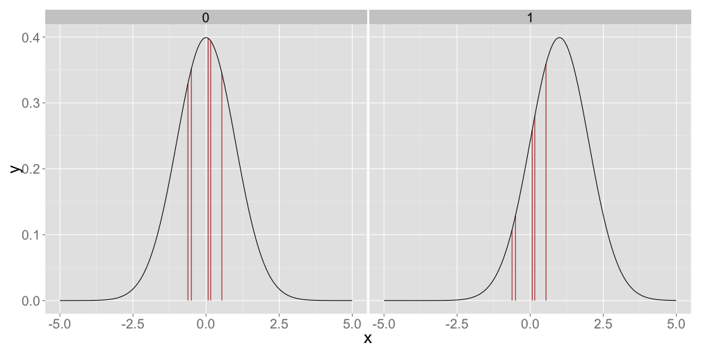

### Maximizing likelihood

```r
logL <- function(coefs, y, x, sdr) {
  means <- coefs[1] + coefs[2] * x
  dat <- cbind(y, means, sdr)
  ll <- apply(dat, 1, function(x) dnorm(x[1], mean = x[2], sd = x[3]))
  return(sum(log(ll)))
}
bootS <- function(model.formula, df) {
  new.df <- df[sample(nrow(df), nrow(df), replace = TRUE),]
  mod <- lm(model.formula, data = new.df)
  return(coef(mod))
}
getRSD <- function(coefs, y, x) {
  y.hat <- coefs[1] + coefs[2] * x
  resids <- y - y.hat
  return(sd(resids))
}
```

### Outputs for ML (lm vs. bootstrap)

```r
data(women)
fit <- lm(weight ~ height, data = women)
fit.ll <- logL(coef(fit), women$weight, women$height, sd(residuals(fit)))
b <- t(replicate(100, bootS(weight ~ height, women)))
rsds <- apply(b, 1, function(x) getRSD(x, women$weight, women$height))
a <- cbind(b, rsds)
all.lls <- apply(a, 1, function(x) logL(x[1:2], women$weight, women$height, x[3]))
c(fit.ll, max(all.lls))
```

```
[1] -26.558 -26.564
```

### Random search

A class of optimization methods that can be used with problems that are not continuous or differentiable. Encompasses two general approaches.

## Point estimation

Find a maximum/minimum point for some outcome. A lot of you probably think of information criteria in this way.

## Distribution estimation

A sampling procedure that converges to a distribution rather than a single point. This is what we'll be doing.

### Quick point-estimation example

Say we have a normal distribution and need to find the x value for which f(x) is maximized. We'll set up a toy example for which the true maximized value is 0.

```r
xs <- runif(10000, -3, 10)
xs[dnorm(xs) == max(dnorm(xs))]
```

```
[1] 2.51e-05
```

I can't honest recommend this method, but it's a very simple demonstration of how random search could work.

### Markov chains

Kruschke's island-hopping example is the clearest explanation I've ever heard for this.

```r
islands <- 1:6
visits <- rep(NA, times = 100000)
visits[1] <- sample(islands, 1)
for (i in 1:(length(visits) - 1)) {
  if (visits[i] == 1) {
    choose.direction <- sample(c(0, 1), 1)
  } else if (visits[i] == 6) {
    choose.direction <- sample(c(-1, 0), 1)
  } else {
    choose.direction <- sample(c(-1, 1), 1)
  }
  if (islands[visits[i]] < islands[visits[i] + choose.direction]) {
    visits[i + 1] <- visits[i] + choose.direction
  } else if (runif(1) < islands[visits[i] + choose.direction]/islands[visits[i]]) {
    visits[i + 1] <- islands[visits[i]] + choose.direction
  } else {
    visits[i + 1] <- visits[i]
  }
}
```

### Island example output

```r
mcmc.approx <- table(visits)/length(visits)
true.props <- islands/sum(islands)
names(true.props) <- names(mcmc.approx)

mcmc.approx
```

```
visits
     1      2      3      4      5      6
0.0465 0.0940 0.1435 0.1924 0.2394 0.2842
```

```r
true.props
```

```
     1      2      3      4      5      6
0.0476 0.0952 0.1429 0.1905 0.2381 0.2857
```